# Final_Project

Cathy Zhuang

2022-11-24

bba: 0 no, 1 yes level: 1 analyst, 2 team lead, 3 director, 4 exec housing: 0 on-campus, 1 off-campus

```r
library(statnet)
library(kableExtra)
library(dplyr)
library(mvmeta)
library(sna)
library(keyplayer)
library(NbClust)

setwd("C:/Users/Cathy/Desktop/QTM 385 Network Analysis")
data <- as.matrix(read.csv("club_network.csv", header = T))

### Create a network object
Fnet <- network(data, directed = T)

### Import and set attributes for nodes
att <- read.csv("club_att.csv", header = T, row.names = 1 )
att$year <- 5 - (att$year - 2022)
att$bba <- att$bba - 1
att$housing <- att$housing - 1

set.vertex.attribute( Fnet, "year", att$year )
set.vertex.attribute( Fnet, "bba", att$bba)
set.vertex.attribute( Fnet, "level", att$level )
set.vertex.attribute( Fnet, "housing", att$housing )
```

Plot the network with nodes colored by “Level”.

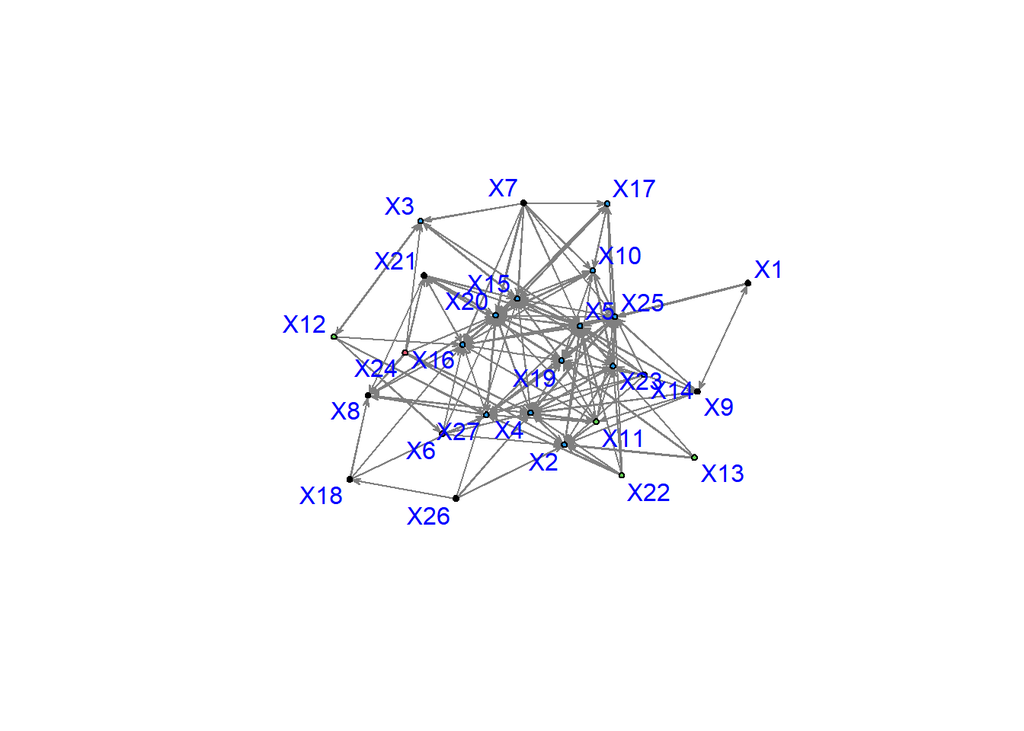

```r
plot.network(Fnet, displaylabels = T, boxed.labels = FALSE, vertex.cex = 0.6, label.cex = 1,
             vertex.col = att$level, label.col = "blue", edge.lwd = .5, edge.col = "gray50")
```

Make a table showing each actor’s degree, betweenness, closeness, and eigenvector centrality. Show the correlations across these measures.

```r
indeg <- degree(Fnet, cmode = "indegree") # indegree centrality
outdeg <- degree(Fnet, cmode = "outdegree") # outdegree centrality

closeness <- closeness(Fnet, cmode="suminvdir") # closeness centrality
betweenness <- betweenness(Fnet) # betweenness centrality
ecent <- evcent(Fnet) # eigenvector centrality
member <- as.vector(1:length(data[,1]))



tab1 <- cbind(member, indeg, outdeg, closeness, betweenness, ecent)
colnames(tab1) <- c("Member","In-Degree","Out-Degree","Closeness", "Betweenness", "Eigenvector")
tab1 %>%
  kbl(caption = "Centrality Measures of Each Club Member") %>%
  kable_classic_2(full_width = F)
```

Centrality Measures of Each Club Member

| Member | In-Degree | Out-Degree | Closeness | Betweenness | Eigenvector |
| --- | --- | --- | --- | --- | --- |
| 1 | 1 | 3 | 0.3698718 | 0.000000 | 0.1053538 |
| 2 | 12 | 2 | 0.3314103 | 3.300000 | 0.0783334 |
| 3 | 4 | 3 | 0.3878205 | 50.819048 | 0.0874711 |
| 4 | 14 | 9 | 0.5224359 | 101.492888 | 0.2929532 |
| 5 | 17 | 7 | 0.4775641 | 44.954792 | 0.2283985 |
| 6 | 1 | 5 | 0.4326923 | 5.809524 | 0.1461700 |
| 7 | 0 | 8 | 0.5096154 | 0.000000 | 0.2516602 |
| 8 | 6 | 1 | 0.3185897 | 5.909524 | 0.0440164 |
| 9 | 2 | 7 | 0.4532051 | 27.366667 | 0.2084978 |
| 10 | 6 | 8 | 0.4871795 | 9.016270 | 0.2374369 |
| 11 | 3 | 9 | 0.5044872 | 6.513370 | 0.2857038 |
| 12 | 1 | 4 | 0.4070513 | 27.233333 | 0.0967156 |
| 13 | 0 | 3 | 0.3794872 | 0.000000 | 0.0833000 |
| 14 | 0 | 8 | 0.5160256 | 0.000000 | 0.2696173 |
| 15 | 13 | 8 | 0.5064103 | 95.075030 | 0.2570540 |
| 16 | 10 | 7 | 0.4679487 | 31.543254 | 0.2217448 |
| 17 | 4 | 4 | 0.3974359 | 0.913370 | 0.1313643 |
| 18 | 1 | 3 | 0.3666667 | 2.833333 | 0.0682243 |
| 19 | 10 | 7 | 0.4679487 | 38.292369 | 0.2476753 |
| 20 | 14 | 8 | 0.4903846 | 42.522802 | 0.2471762 |
| 21 | 3 | 6 | 0.4487179 | 3.360714 | 0.1872220 |
| 22 | 0 | 6 | 0.4532051 | 0.000000 | 0.1780348 |
| 23 | 10 | 4 | 0.4019231 | 4.237179 | 0.1326342 |
| 24 | 0 | 6 | 0.4807692 | 0.000000 | 0.1408106 |
| 25 | 15 | 8 | 0.4967949 | 39.489988 | 0.2642908 |
| 26 | 0 | 4 | 0.4519231 | 0.000000 | 0.1046593 |
| 27 | 7 | 6 | 0.4371795 | 13.316545 | 0.1883093 |

```r
tab2 <- cbind(indeg, outdeg, closeness, betweenness, ecent)
colnames(tab2) <- c("In-Degree","Out-Degree","Closeness", "Betweenness", "Eigenvector")
cor(tab2) %>%
  kbl(caption = "Correlations Among Centrality Measures") %>%
  kable_classic_2(full_width = F) # show correlations among centrality measures
```

Correlations Among Centrality Measures

|  | In-Degree | Out-Degree | Closeness | Betweenness | Eigenvector |
| --- | --- | --- | --- | --- | --- |
| In-Degree | 1.0000000 | 0.3115228 | 0.2164953 | 0.6712879 | 0.4079687 |
| Out-Degree | 0.3115228 | 1.0000000 | 0.9637096 | 0.4355329 | 0.9773765 |
| Closeness | 0.2164953 | 0.9637096 | 1.0000000 | 0.4076208 | 0.9193700 |
| Betweenness | 0.6712879 | 0.4355329 | 0.4076208 | 1.0000000 | 0.4652002 |
| Eigenvector | 0.4079687 | 0.9773765 | 0.9193700 | 0.4652002 | 1.0000000 |

List the four members with the highest individual indegree. Calculate the total number of unique incoming connections they have in the network.

```r
deg1 <- degree(data, cmode = "indegree")
names(deg1) <- seq(1, 27, 1)
ids <- as.numeric(names(sort(deg1, decreasing=T)[1:4])) # Find the ids of the most central four individuals
ids %>%
  kbl(caption = "Top 4 Members with highest individual indegree") %>%
  kable_classic_2(full_width = F)
```

Top 4 Members with highest individual indegree

| x |
| --- |
| 5 |
| 25 |
| 4 |
| 20 |

```r
kpcent(data,ids,type="degree", cmode="indegree", method = "max") %>%
  kbl(caption = "Total  number of unique incoming connections of the fourmembers") %>%
  kable_classic_2(full_width = F)
```

Total number of unique incoming connections of the fourmembers

| x |
| --- |
| 21 |

List the four members with the highest group indegree. Calculate the total number of unique incoming connections they have in the network.

```r
groupind <- kpset(data,size=4,type="degree", cmode="indegree", method = "max")
groupind$keyplayers %>%
  kbl(caption = "Top 4 Members with highest group indegree") %>%
  kable_classic_2(full_width = F)
```

Top 4 Members with highest group indegree

| x |
| --- |
| 4 |
| 5 |
| 16 |
| 20 |

```r
groupind$centrality %>%
  kbl(caption = "Total  number of unique incoming connections of the four members") %>%
  kable_classic_2(full_width = F)
```

Total number of unique incoming connections of the four members

| x |
| --- |
| 23 |

Run a linear regression to predict the in-degree centrality using the members’ attributes.

```r
regression <- cbind(indeg, att)
regression1 <- lm(indeg ~ year + bba + level + housing, data = regression)

regression1$coefficients %>%
  kbl( caption = "Linear Regression of In-Degree Centrality Using Member Attributes") %>%
  kable_classic_2(full_width = F)
```

Linear Regression of In-Degree Centrality Using Member Attributes

|  | x |
| --- | --- |
| (Intercept) | -6.9973056 |
| year | 2.1095888 |
| bba | 0.2618660 |
| level | 2.1685732 |
| housing | -0.7506741 |

List all the cliques with 3 or more members.

```r
clique <- clique.census(Fnet)

# See clique counts
cliquecounts <- clique$clique.count[,1]
cliquecounts
```

```
##  1  2  3  4  5
##  9 11  5  1  1
```

```r
# From the clique counts we can see that there are cliques with 4 and 5 members (cliques with 3 or more members)

tab3 <- clique$cliques[c(3,4,5)]

tab5 <- data.frame(clique$cliques[3])
colnames(tab5) <- c(1:length(tab5))
tab5  %>%
  kbl(caption = "Cliques with 3 Members") %>%
  kable_classic_2(full_width = F)
```

Cliques with 3 Members

| 1 | 2 | 3 | 4 | 5 |
| --- | --- | --- | --- | --- |
| 10 | 10 | 15 | 5 | 2 |
| 15 | 15 | 16 | 19 | 4 |
| 20 | 17 | 25 | 25 | 5 |

```r
tab6 <- data.frame(clique$cliques[4])
colnames(tab6) <- c(1:length(tab6))
tab6 %>%
  kbl(caption = "Cliques with 4 Members") %>%
  kable_classic_2(full_width = F)
```

Cliques with 4 Members

| 1 |
| --- |
| 4 |
| 20 |
| 23 |
| 25 |

```r
tab7 <- data.frame(clique$cliques[5])
colnames(tab7) <- c(1:length(tab7))
tab7  %>%
  kbl(caption = "Cliques with 5 Members") %>%
  kable_classic_2(full_width = F)
```

Cliques with 5 Members

| 1 |
| --- |
| 4 |
| 5 |
| 15 |
| 20 |
| 25 |

Calculate the mutuality, density, centralization, and transitivity of the network. Provide boxplots that compare these statistics in the actual network with those in randomized networks.

```r
# mutuality
mutuality <- grecip(Fnet, measure = "edgewise")
print(paste0("The mutuality is ", mutuality))
```

```
## [1] "The mutuality is 0.441558441558442"
```

```r
# density
density <- gden(Fnet)
print(paste0("The density is ", density))
```

```
## [1] "The density is 0.219373219373219"
```

```r
# centralization
cent <- centralization(Fnet, degree)
print(paste0("The centralization is ", cent))
```

```
## [1] "The centralization is 0.261538461538462"
```

```r
# transitivity
transitivity <- gtrans(Fnet)
print(paste0("The transitivity is ", transitivity))
```

```
## [1] "The transitivity is 0.485245901639344"
```

[figure not shown]

```r
##### Randomization test for network structures


### Randomize the network and get the statistics/estimates
## Fix the number of ties each actor sent
## But randomize to whom the ties are directed to
## Vectors to store statistics from randomized networks
mut <- NULL
trans <- NULL
dens <- NULL
centr <- NULL

# Get the adjacency matrix
FMat <- as.matrix(Fnet)
K <- nrow(FMat)
# number of randomization
M <- 200

for (i in 1:M) {
  S <- sample(K)
  RMat <- FMat[, S]
  RNet <- network(RMat)

  mut <- append(mut, grecip(RNet, measure = "edgewise"))
  dens <- append(dens, gden(RNet))
  centr <- append(centr, centralization(RNet, degree))
  trans <- append(trans, gtrans(RNet))
}

boxplot(mut, ylim=c(0,1.2), main = "Mutuality of Network Compared to Randomized Network"  )
abline(h=density, col = "Red")
```

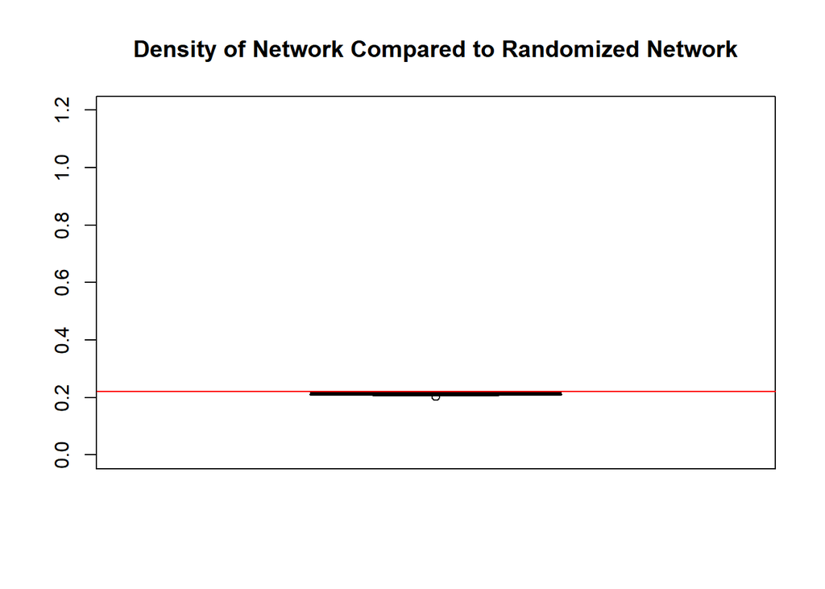

```r
boxplot(dens, ylim=c(0,1.2), main = "Density of Network Compared to Randomized Network"  )
abline(h=density, col = "Red")
```

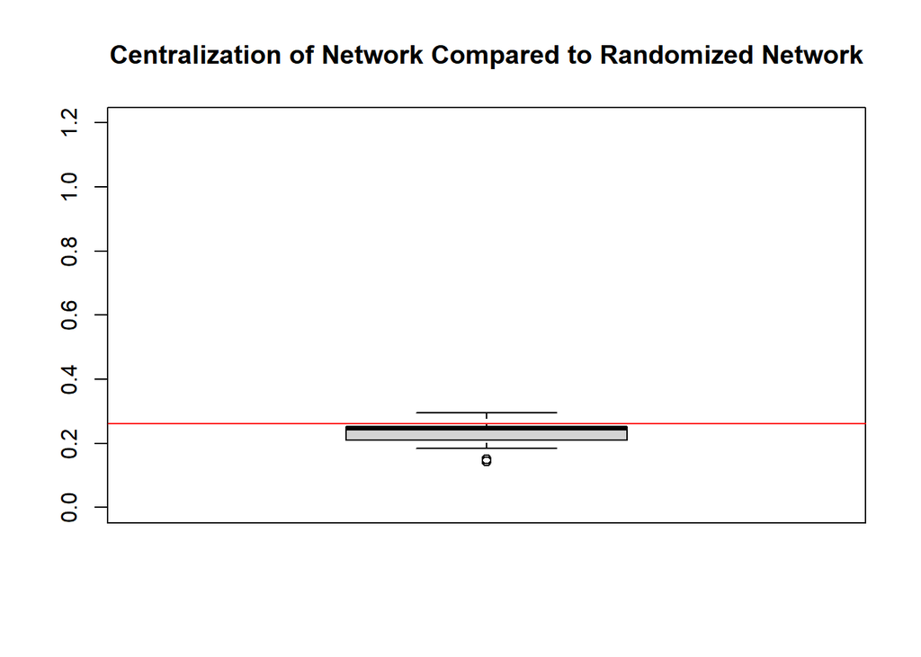

```r
boxplot(centr, ylim=c(0,1.2), main = "Centralization of Network Compared to Randomized Network"  )
abline(h=cent, col = "Red")
```

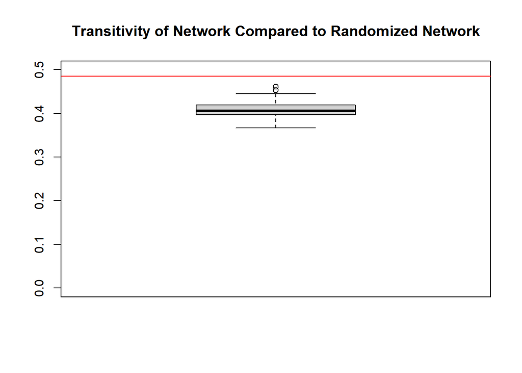

```r
boxplot(trans, ylim=c(0,0.5), main = "Transitivity of Network Compared to Randomized Network" )
abline(h=transitivity, col = "Red")
```

Use “brokerage” and “level” to calculate a brokerage index (i.e., the total number of times an actor serving as a broker). Which three actors have the highest brokerage power? How much does your brokerage index correlate with the betweenness centrality?

```r
sb <- brokerage(Fnet, att$level)
# Observed brokerage scores, by vertex. t column shows the total roles.
sb$raw.nli %>%
  kbl(caption = "Brokerage Index") %>%
  kable_classic_2(full_width = F)
```

Brokerage Index

|  | w_I | w_O | b_IO | b_OI | b_O | t |
| --- | --- | --- | --- | --- | --- | --- |
| X1 | 0 | 0 | 0 | 0 | 0 | 0 |
| X2 | 3 | 0 | 0 | 4 | 0 | 7 |
| X3 | 0 | 0 | 1 | 4 | 2 | 7 |
| X4 | 16 | 3 | 14 | 28 | 8 | 69 |
| X5 | 30 | 0 | 0 | 26 | 0 | 56 |
| X6 | 0 | 0 | 0 | 0 | 4 | 4 |
| X7 | 0 | 0 | 0 | 0 | 0 | 0 |
| X8 | 0 | 2 | 2 | 0 | 0 | 4 |
| X9 | 0 | 0 | 4 | 1 | 0 | 5 |
| X10 | 20 | 0 | 0 | 3 | 0 | 23 |
| X11 | 0 | 7 | 0 | 0 | 4 | 11 |
| X12 | 0 | 2 | 0 | 0 | 1 | 3 |
| X13 | 0 | 0 | 0 | 0 | 0 | 0 |
| X14 | 0 | 0 | 0 | 0 | 0 | 0 |
| X15 | 40 | 0 | 0 | 13 | 0 | 53 |
| X16 | 3 | 3 | 7 | 17 | 6 | 36 |
| X17 | 2 | 0 | 0 | 1 | 0 | 3 |
| X18 | 1 | 0 | 2 | 0 | 0 | 3 |
| X19 | 12 | 1 | 12 | 9 | 3 | 37 |
| X20 | 27 | 1 | 7 | 21 | 2 | 58 |
| X21 | 0 | 2 | 0 | 1 | 4 | 7 |
| X22 | 0 | 0 | 0 | 0 | 0 | 0 |
| X23 | 6 | 0 | 0 | 3 | 0 | 9 |
| X24 | 0 | 0 | 0 | 0 | 0 | 0 |
| X25 | 32 | 0 | 0 | 22 | 0 | 54 |
| X26 | 0 | 0 | 0 | 0 | 0 | 0 |
| X27 | 6 | 0 | 2 | 11 | 3 | 22 |

```r
tab8 <- cbind(betweenness, sb$raw.nli)
cor(tab8) %>%
  kbl(caption = "Correlation of Brokerage Index with Betweenness Centrality") %>%
  kable_classic_2(full_width = F)
```

Correlation of Brokerage Index with Betweenness Centrality

|  | betweenness | w_I | w_O | b_IO | b_OI | b_O | t |
| --- | --- | --- | --- | --- | --- | --- | --- |
| betweenness | 1.0000000 | 0.6900162 | 0.1462588 | 0.5673435 | 0.7588393 | 0.4238401 | 0.8243981 |
| w_I | 0.6900162 | 1.0000000 | -0.1186374 | 0.1862511 | 0.7654057 | -0.0255733 | 0.8655350 |
| w_O | 0.1462588 | -0.1186374 | 1.0000000 | 0.2992689 | 0.1069903 | 0.6271027 | 0.1628937 |
| b_IO | 0.5673435 | 0.1862511 | 0.2992689 | 1.0000000 | 0.5508610 | 0.6620750 | 0.5781720 |
| b_OI | 0.7588393 | 0.7654057 | 0.1069903 | 0.5508610 | 1.0000000 | 0.4211450 | 0.9563566 |
| b_O | 0.4238401 | -0.0255733 | 0.6271027 | 0.6620750 | 0.4211450 | 1.0000000 | 0.4114043 |
| t | 0.8243981 | 0.8655350 | 0.1628937 | 0.5781720 | 0.9563566 | 0.4114043 | 1.0000000 |

What does structural equivalence mean here? Show the structural equivalence matrix. Based on the structural equivalence matrix, present a hierarchical clustering of the actors.

In this case, two members are considered structurally equivalent if they are connected to other members in a similar way.

```r
se <- sedist (Fnet, method = "euclidean") # use euclidean distance
se[upper.tri(se)] <- ""
se <- as.data.frame(se)
se <- cbind(a = c(1:nrow(se)), se)
se <- as.data.frame(apply(se, 2, as.numeric))
se <- se %>%
  mutate(across(where(is.numeric), round, digits=1))
colnames(se) <- c(0:(ncol(se)-1))


se  %>%
  kbl(caption = "Structural Equivalence Matrix") %>%
  kable_classic_2(full_width = F)
```

Structural Equivalence Matrix

| 0 | 1 | 2 | 3 | 4 | 5 | 6 | 7 | 8 | 9 | 10 | 11 | 12 | 13 | 14 | 15 | 16 | 17 | 18 | 19 | 20 | 21 | 22 | 23 | 24 | 25 | 26 | 27 |
| --- | --- | --- | --- | --- | --- | --- | --- | --- | --- | --- | --- | --- | --- | --- | --- | --- | --- | --- | --- | --- | --- | --- | --- | --- | --- | --- | --- |
| 1 | 0.0 | NA | NA | NA | NA | NA | NA | NA | NA | NA | NA | NA | NA | NA | NA | NA | NA | NA | NA | NA | NA | NA | NA | NA | NA | NA | NA |
| 2 | 3.7 | 0.0 | NA | NA | NA | NA | NA | NA | NA | NA | NA | NA | NA | NA | NA | NA | NA | NA | NA | NA | NA | NA | NA | NA | NA | NA | NA |
| 3 | 3.0 | 4.1 | 0.0 | NA | NA | NA | NA | NA | NA | NA | NA | NA | NA | NA | NA | NA | NA | NA | NA | NA | NA | NA | NA | NA | NA | NA | NA |
| 4 | 4.4 | 3.6 | 4.7 | 0.0 | NA | NA | NA | NA | NA | NA | NA | NA | NA | NA | NA | NA | NA | NA | NA | NA | NA | NA | NA | NA | NA | NA | NA |
| 5 | 4.7 | 4.5 | 4.8 | 3.9 | 0.0 | NA | NA | NA | NA | NA | NA | NA | NA | NA | NA | NA | NA | NA | NA | NA | NA | NA | NA | NA | NA | NA | NA |
| 6 | 3.2 | 4.0 | 3.3 | 4.6 | 4.7 | 0.0 | NA | NA | NA | NA | NA | NA | NA | NA | NA | NA | NA | NA | NA | NA | NA | NA | NA | NA | NA | NA | NA |
| 7 | 2.8 | 4.5 | 3.0 | 4.8 | 4.9 | 3.2 | 0.0 | NA | NA | NA | NA | NA | NA | NA | NA | NA | NA | NA | NA | NA | NA | NA | NA | NA | NA | NA | NA |
| 8 | 3.3 | 4.1 | 3.5 | 4.9 | 4.6 | 3.3 | 3.9 | 0.0 | NA | NA | NA | NA | NA | NA | NA | NA | NA | NA | NA | NA | NA | NA | NA | NA | NA | NA | NA |
| 9 | 2.2 | 3.9 | 3.7 | 4.2 | 4.4 | 3.0 | 3.6 | 3.7 | 0.0 | NA | NA | NA | NA | NA | NA | NA | NA | NA | NA | NA | NA | NA | NA | NA | NA | NA | NA |
| 10 | 4.0 | 4.9 | 3.9 | 4.4 | 4.0 | 3.5 | 3.2 | 4.4 | 4.1 | 0.0 | NA | NA | NA | NA | NA | NA | NA | NA | NA | NA | NA | NA | NA | NA | NA | NA | NA |
| 11 | 3.2 | 4.0 | 4.1 | 4.1 | 4.0 | 2.8 | 3.5 | 4.1 | 2.6 | 3.5 | 0.0 | NA | NA | NA | NA | NA | NA | NA | NA | NA | NA | NA | NA | NA | NA | NA | NA |
| 12 | 3.0 | 4.4 | 2.8 | 5.3 | 5.2 | 2.6 | 3.0 | 3.5 | 3.7 | 4.1 | 3.6 | 0.0 | NA | NA | NA | NA | NA | NA | NA | NA | NA | NA | NA | NA | NA | NA | NA |
| 13 | 2.2 | 3.6 | 2.8 | 4.5 | 4.6 | 2.6 | 3.0 | 3.2 | 2.8 | 3.6 | 3.0 | 2.8 | 0.0 | NA | NA | NA | NA | NA | NA | NA | NA | NA | NA | NA | NA | NA | NA |
| 14 | 2.8 | 4.0 | 3.3 | 4.4 | 4.5 | 3.2 | 2.8 | 3.6 | 3.0 | 3.5 | 2.8 | 3.3 | 2.2 | 0.0 | NA | NA | NA | NA | NA | NA | NA | NA | NA | NA | NA | NA | NA |
| 15 | 4.6 | 4.6 | 4.5 | 4.9 | 4.1 | 4.6 | 3.6 | 4.5 | 4.7 | 3.6 | 4.4 | 4.5 | 4.7 | 4.4 | 0.0 | NA | NA | NA | NA | NA | NA | NA | NA | NA | NA | NA | NA |
| 16 | 4.1 | 4.8 | 3.7 | 4.7 | 4.4 | 4.1 | 3.9 | 4.0 | 4.7 | 4.1 | 4.4 | 4.5 | 4.0 | 4.1 | 4.5 | 0.0 | NA | NA | NA | NA | NA | NA | NA | NA | NA | NA | NA |
| 17 | 3.5 | 4.5 | 3.0 | 4.6 | 4.5 | 3.2 | 2.8 | 3.9 | 3.9 | 2.8 | 4.0 | 3.6 | 3.3 | 3.5 | 3.9 | 3.6 | 0.0 | NA | NA | NA | NA | NA | NA | NA | NA | NA | NA |
| 18 | 2.8 | 4.0 | 3.3 | 5.0 | 5.3 | 2.8 | 3.2 | 3.0 | 3.6 | 4.0 | 3.5 | 2.2 | 2.6 | 3.2 | 4.6 | 4.1 | 3.5 | 0.0 | NA | NA | NA | NA | NA | NA | NA | NA | NA |
| 19 | 4.1 | 4.1 | 4.5 | 4.7 | 4.1 | 4.8 | 4.1 | 4.2 | 4.2 | 4.6 | 4.1 | 4.5 | 4.0 | 3.6 | 4.0 | 3.7 | 4.1 | 4.4 | 0.0 | NA | NA | NA | NA | NA | NA | NA | NA |
| 20 | 4.7 | 4.2 | 4.4 | 4.4 | 4.2 | 4.7 | 4.5 | 4.1 | 4.6 | 4.5 | 4.5 | 5.0 | 4.8 | 4.2 | 3.9 | 3.6 | 3.7 | 4.7 | 3.6 | 0.0 | NA | NA | NA | NA | NA | NA | NA |
| 21 | 3.3 | 4.4 | 3.2 | 4.7 | 4.6 | 3.3 | 3.0 | 3.2 | 4.0 | 3.6 | 3.3 | 3.5 | 2.8 | 3.3 | 4.2 | 3.5 | 3.6 | 3.0 | 4.0 | 4.4 | 0.0 | NA | NA | NA | NA | NA | NA |
| 22 | 2.4 | 3.7 | 3.3 | 4.4 | 4.5 | 2.4 | 3.2 | 3.3 | 2.2 | 3.7 | 2.4 | 3.0 | 2.2 | 2.0 | 4.6 | 4.4 | 3.5 | 2.8 | 4.1 | 4.2 | 3.6 | 0.0 | NA | NA | NA | NA | NA |
| 23 | 3.7 | 3.2 | 4.6 | 3.6 | 4.0 | 3.5 | 4.2 | 4.1 | 3.6 | 4.0 | 3.5 | 4.4 | 3.9 | 4.0 | 4.1 | 4.4 | 3.7 | 4.2 | 4.4 | 3.7 | 4.6 | 3.5 | 0.0 | NA | NA | NA | NA |
| 24 | 3.2 | 4.0 | 3.3 | 4.8 | 4.9 | 2.4 | 3.2 | 3.0 | 3.3 | 4.0 | 3.5 | 3.0 | 2.6 | 3.2 | 4.6 | 4.1 | 3.5 | 2.8 | 4.6 | 4.7 | 3.0 | 2.8 | 3.7 | 0.0 | NA | NA | NA |
| 25 | 4.6 | 4.1 | 4.7 | 4.0 | 3.0 | 4.6 | 4.4 | 4.7 | 4.5 | 3.6 | 3.9 | 5.1 | 4.7 | 4.6 | 3.7 | 4.2 | 4.1 | 5.0 | 4.2 | 3.9 | 4.2 | 4.6 | 3.9 | 5.0 | 0.0 | NA | NA |
| 26 | 2.8 | 3.7 | 3.0 | 4.6 | 4.7 | 2.4 | 3.2 | 3.0 | 3.0 | 3.7 | 3.5 | 3.0 | 2.2 | 2.4 | 4.6 | 4.4 | 3.2 | 2.4 | 4.4 | 4.7 | 3.3 | 2.4 | 3.7 | 2.4 | 4.8 | 0.0 | NA |
| 27 | 3.6 | 4.4 | 4.0 | 4.5 | 4.4 | 3.6 | 3.6 | 3.7 | 4.2 | 3.6 | 3.3 | 3.7 | 3.5 | 3.6 | 4.5 | 3.5 | 4.4 | 3.3 | 4.2 | 4.8 | 3.2 | 3.6 | 4.1 | 3.9 | 4.0 | 4.1 | 0 |

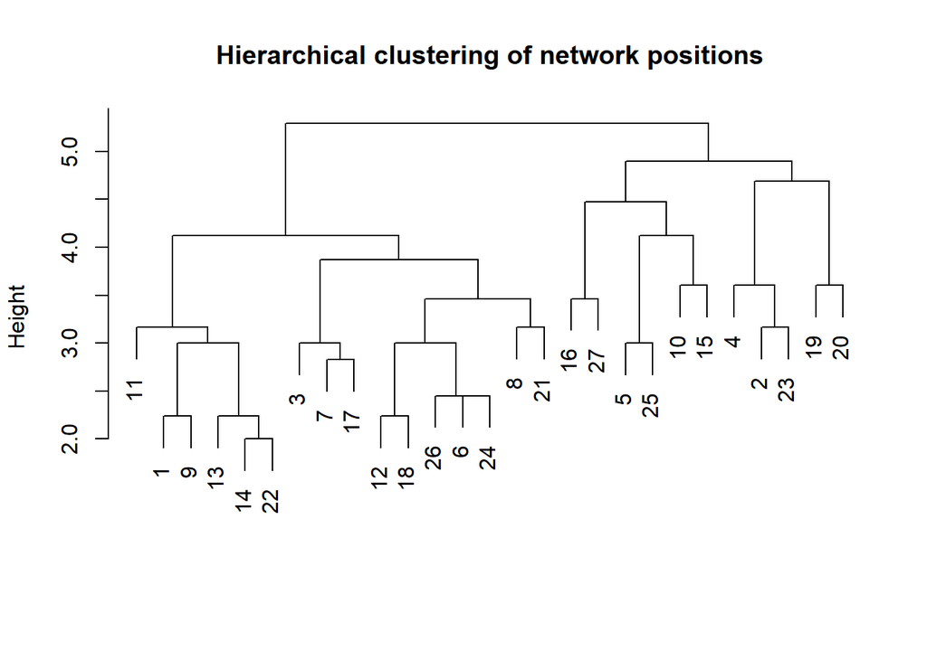

```r
# Hierarchical clustering of network positions
eq <- equiv.clust (Fnet, method="euclidean") # use euclidean distance

plot(eq, main="Hierarchical clustering of network positions", xlab = "", sub="")
```

Divide the actors into three blocks based on structural equivalence. Present the density matrix of the three blocks.

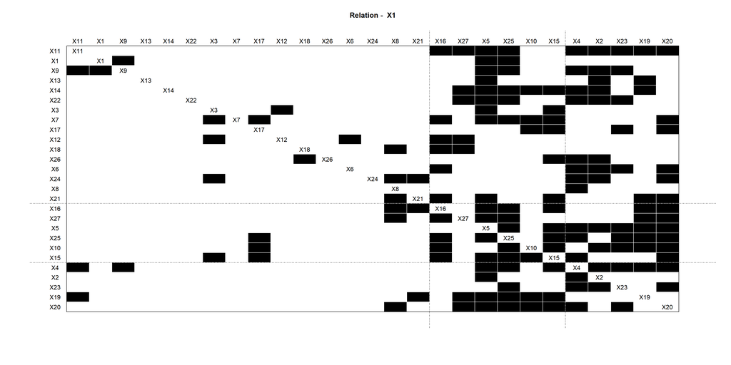

```r
# This approach maximizes structural equivalence within blocks.
# divide into blocks, let's do 3 blocks
block <- blockmodel(Fnet, eq, k = 3 )


# block modeling
plot(block, displaylabels = F, xlab="", ylab="", main="Blockgrouping", sub="")
```

```r
block$block.model %>%
  kbl(caption = "Density Matrix of 3 Blocks") %>%
  kable_classic_2(full_width = F)
```

Density Matrix of 3 Blocks

|  | Block 1 | Block 2 | Block 3 |
| --- | --- | --- | --- |
| Block 1 | 0.0583333 | 0.3875000 | 0.3645833 |
| Block 2 | 0.0625000 | 0.5000000 | 0.5000000 |
| Block 3 | 0.0729167 | 0.6333333 | 0.6000000 |

```r
# gives you density table, also tells you which manager belongs to which blocks
```